# DAB501 Project #1 - Data Visualization

Alejandro Rodriguez (w0795089) and Jenson Jacob (w0794547)

2022-06-10

# Academic Integrity policies statement

We acknowledge and abide to the policies of St.clair college and followed the same in this entire project. [Academic Integrity at St. Clair College](https://www.stclaircollege.ca/academic-integrity)

# R and RStudio environment

- RStudio : 2022.02.3+492
- R : 4.2.0
- Libraries
  - tidyverse
  - knitr
  - ggpubr
  - ggridges

# Documentation of the dataset

## Owner/creator of the data

The dataset that we chose for developing this project is [2022 Fuel Consumption Ratings](https://www.kaggle.com/datasets/rinichristy/2022-fuel-consumption-ratings) data and the information regarding this data was created by [Open Canada](https://open.canada.ca/data/en/dataset/98f1a129-f628-4ce4-b24d-6f16bf24dd64).

## Summary information about the data

| Variable Name | Description | R Data Type | Statistical Data Type |  |
| --- | --- | --- | --- | --- |
| `Model Year` | Manufactured year of the vehicle | Numerical | Discrete Numerical |  |
| `Make` | Vehicle manufacturer name | Character | Nominal Categorical |  |
| `Model` | Vehicle Model type: 4WD/4X4 = Four-wheel drive; AWD = All-wheel drive; FFV = Flexible-fuel vehicle; SWB = Short | Character | Nominal Categorical |  |
| `Vehicle Class` | Different class of different branded vehicles like SUV, Mid-Size, Two-seater | Character | Nominal Categorical |  |
| `Engine Size` | Size of the engine in liters | Numerical | Continuous Numerical |  |
| `Cylinders` | Number of cylinders | Numerical | Discrete Numerical |  |
| `Transmission` | Transmission: A = automatic; AM = automated manual; AS = automatic with select shift; AV = continuously | Character | Nominal Categorical |  |
| `Fuel type` | Fuel type: Z – Premium Gasoline, D- Diesel, E- Electric, X-Regular Gasoline | Character | Nominal Categorical |  |
| `Fuel Consumption (City (L/100 km)` | City fuel consumption ratings are shown in liters per 100 kilometers (L/100 km) | Numerical | Continuous Numerical |  |
| `Fuel Consumption (Hwy (L/100 km))` | Highway fuel consumption ratings are shown in liters per 100 kilometers (L/100 km) | Numerical | Continuous Numerical |  |
| `Fuel Consumption (Comb (L/100 km))` | The combined rating (55% city, 45% highway) is shown in L/100 km | Numerical | Continuous Numerical |  |
| `Fuel Consumption (Comb (mpg))` | The combined rating (55% city, 45% highway) is shown in miles per imperial gallon (mpg) | Numerical | Discrete Numerical |  |
| `CO2 Emissions(g/km)` | The tailpipe emissions of carbon dioxide (in grams per kilometer) for combined city and highway driving | Numerical | Discrete Numerical |  |
| `CO2 Rating` | The tailpipe emissions of carbon dioxide rated on a scale from 1 (worst) to 10 (best) | Numerical | Discrete Numerical |  |
| `Smog Rating` | The tailpipe emissions of smog-forming pollutants rated on a scale from 1 (worst) to 10 (best) | Numerical | Discrete Numerical |  |

# 1.Distribution of continuous variables

## 1.1 Distribution of fuel consumption in **city**

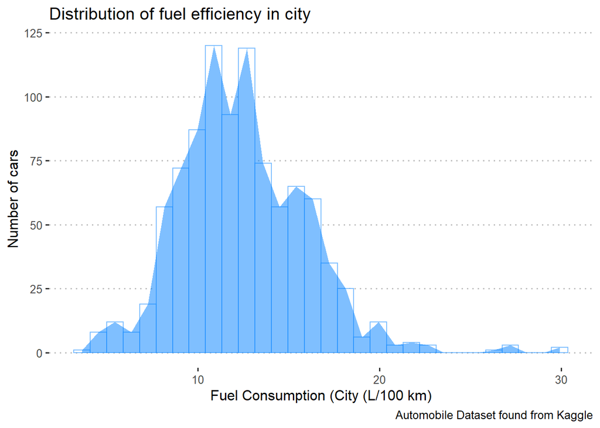

## 1.2 Distribution of fuel consumption in **highway**

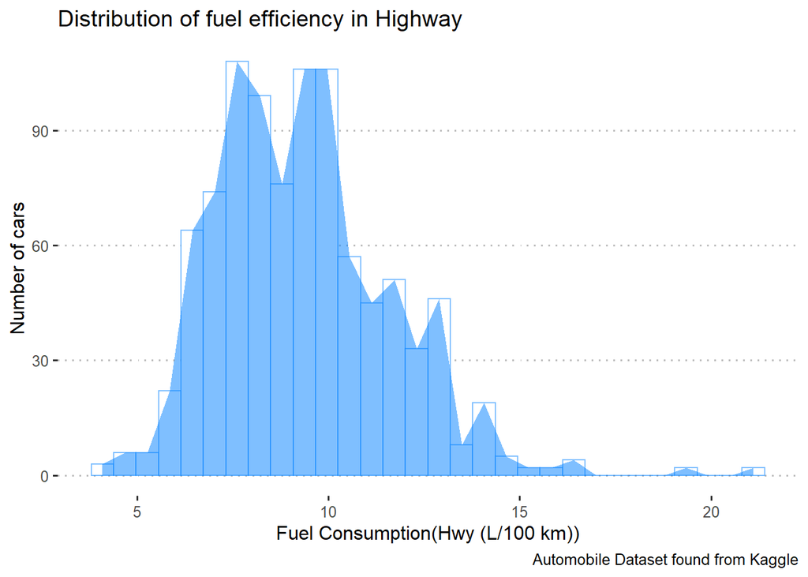

# 2. Distribution of categorical variables

## 2.1 Distribution of vehicle class variable

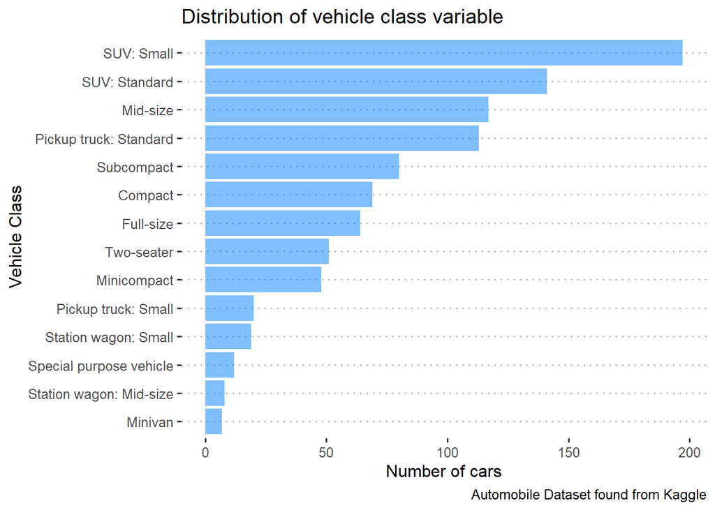

## 2.2 Distribution of vehicle transmission variable

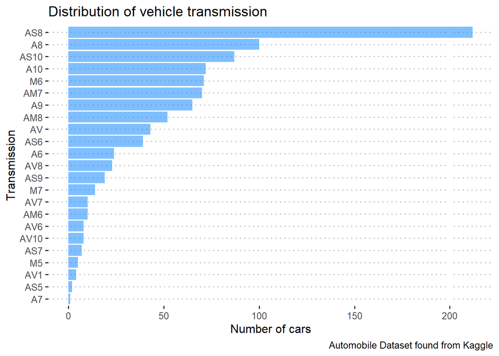

# 3.Relationship between a continuous variable and a categorical variable.

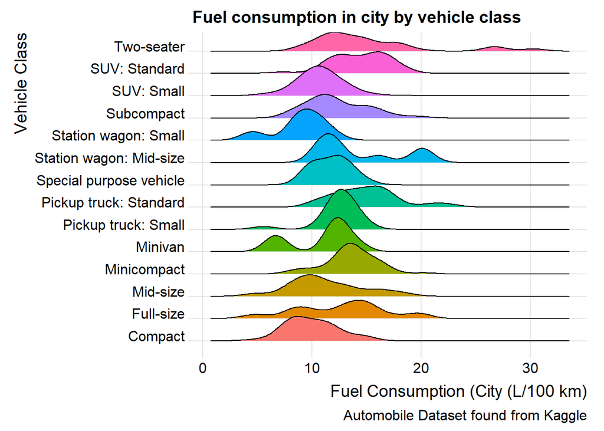

# 4.Relationship between two variables.

## 4.1 Relationship between fuel consumption in city and highway (continuous Vs continuous).

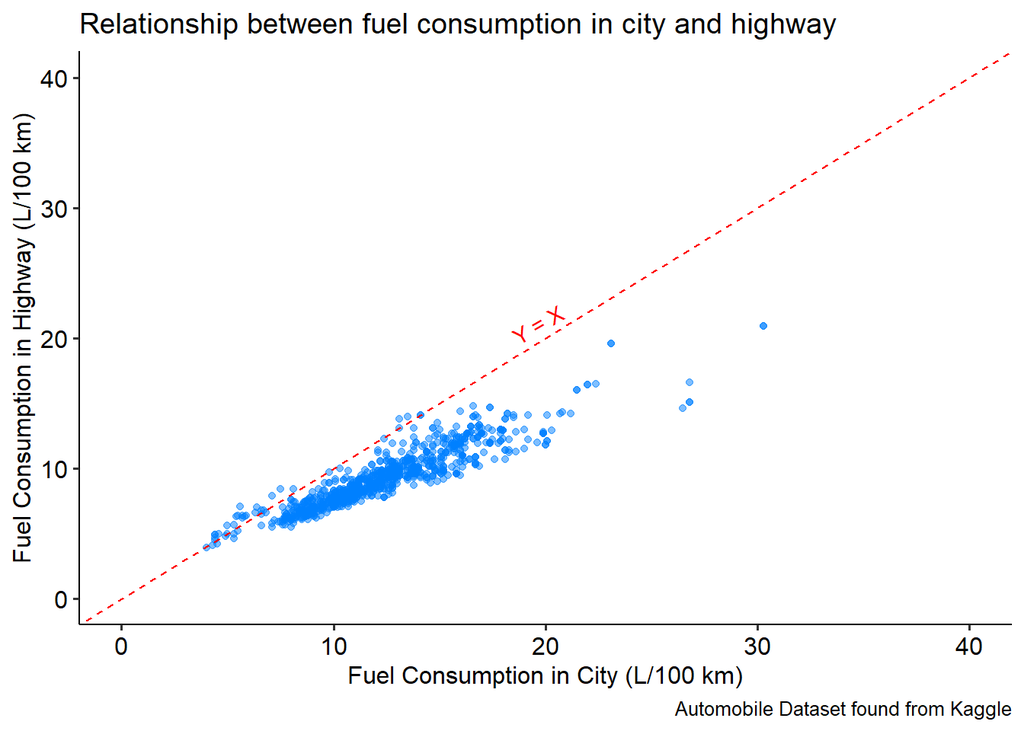

## 4.2 Relationship between vehicle class and fuel type variables (categorical Vs categorical).

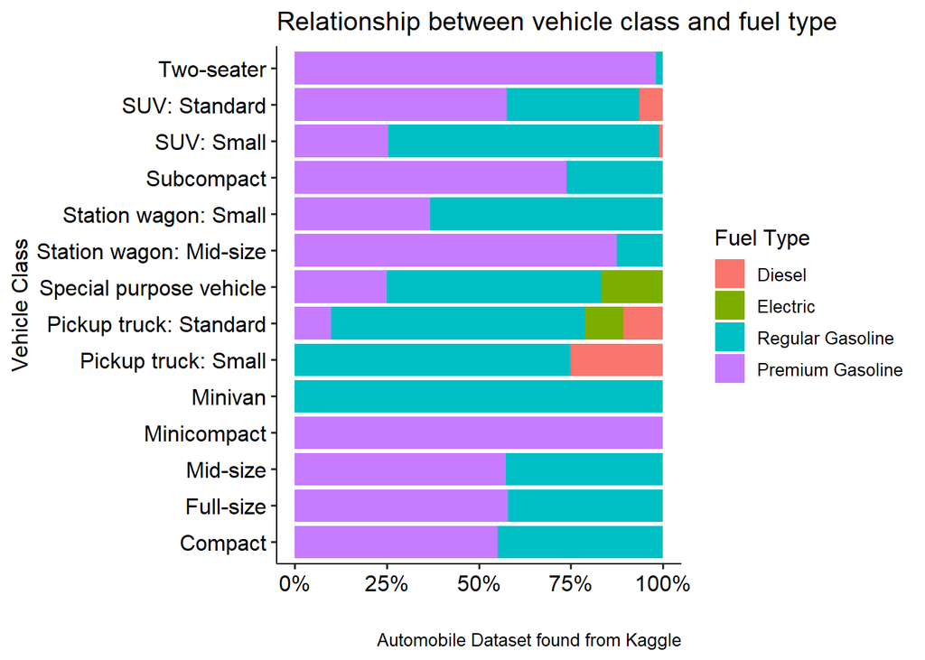

# 5. Relationship among 4 variable using faceting.

[figure not shown]

# References

We referred the following websites for enhancing our knowledge in this project.

-[R for Data Science](https://r4ds.had.co.nz/)  
-[ggplot2 - Tidyverse](https://ggplot2.tidyverse.org/)  
-[The R Graph Galery](https://r-graph-gallery.com/index.html)  
-[STHDA](http://www.sthda.com/english/)

# Questions

**1. In what ways do you think data visualization is important to understanding a data set?**

$“The\ greatest\ value\ of\ a\ picture\ is\ when\ it\ forces\ us\ to\ notice\ what\ we\ never\ expected\ to\ see.”$  
$John\ Wilder\ Tukey$

As the author John says, the least expected details comes out when we try to visualize a data. For ex. An excel sheet can only give you numerical details which makes the user very complicated to understand the bigger picture of the data which he/she is trying to analyze.

**2. In what ways do you think data visualization is important to communicating important aspects of a data set?**

Data visualization is really important to convey what the data depicts to the user. You can view lively the upside and downside trend of any particular data, Visual representation speaks out more than a numeric analysis can ever do.

**3. What role does your integrity as an analyst play when creating a data visualization for communicating results to others?**

$Far\ better\ an\ approximate\ answer\ to\ the\ right$ $question,\ which\ is\ often\ vague,\ than\ an\ exact\ answer$ $to\ the\ wrong\ question,\ which\ can\ always\ be\ made\ precise.”$  
$John\ Wilder\ Tukey$

- Do not transform or alter the representation of the data in order to maximize some aspect that we could consider is most important, we could be biased for some reason, therefore we consider that the best way to show data is showing it in the most natural way as possible.
- Also, we consider that it is really important to state in some part of the chart the source of your data, and by this way we are showing that anybody can get the same data and obtain the same chart, so there is no mystery related with the insights we got it from the graph.

**How many variables do you think you can successfully represent in a visualization? What happens when you exceed this number?**

Data visualization is a tool used to represent the structure and relationships among variables so as we increase the number of variables we are increasing the complexity of those structures and relationships. We think with more than 5 variables, it is really difficult to keep in mind all the possible relationships among those variables in order to get an idea of the message that the analyst is trying to project with his/her visualization. And the reason is that, the human mind can be really acute to drill a problem and find a solution, but when it’s time to do multitasking with several data, human fails at some extent and this is the reason why we need computers.